# Analyse der Herzgesundheitsdaten

Kirill Khvastow, Inga Stakhurska, Stefan Shushpanov

WS 2023/2024

# Einführung

- **Ziel des Projekts:** Untersuchung der Zusammenhänge zwischen verschiedenen Gesundheitsaspekten und Herzkrankheiten.
- **Datenquelle:** Kaggle-Dataset von Amir Mahdiabbootalebi.
- **Schlüsselfragen:** Gibt es einen signifikanten Unterschied im Ruheblutdruck je nach Brustschmerztyp?

# Datensatz

# Explorative Analyse

### Numerische Zusammenfassungen

- Die Tabelle zeigt Minimum, Maximum, Durchschnitt und Varianz für Alter, RestingBP, Cholesterin und MaxHR.

```
##             Minimum Maximum      Mean   Variance
## Age              28      77  52.88204   90.36191
## RestingBP        92     200 133.02279  298.69344
## Cholesterol      85     603 244.63539 3499.13936
## MaxHR            69     202 140.22654  601.43183
```

# Explorative Analyse

### Verteilungen

- Unterschiede im Ruheblutdruck bei verschiedenen Brustschmerztypen.

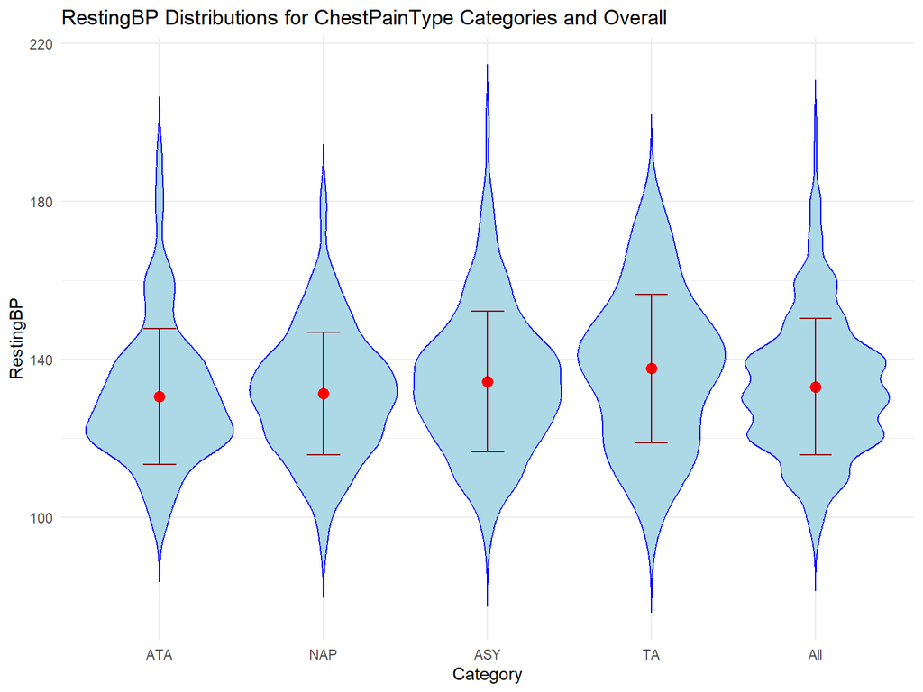

# Explorative Analyse

### Verteilungen

- Normalverteilung von Ruheblutdruck.

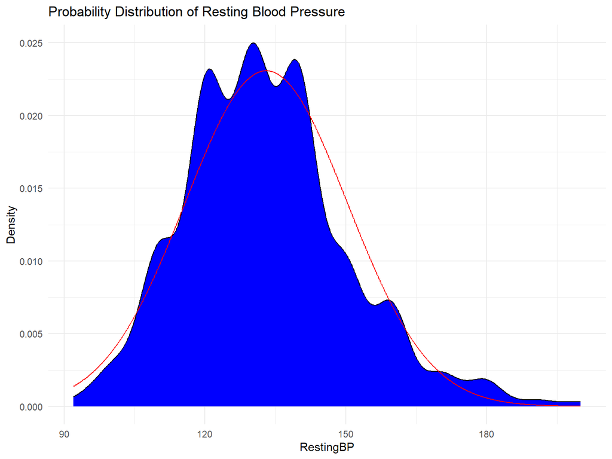

# Explorative Analyse

### Verteilungen

- Normalverteilung von Cholesterinspiegel.

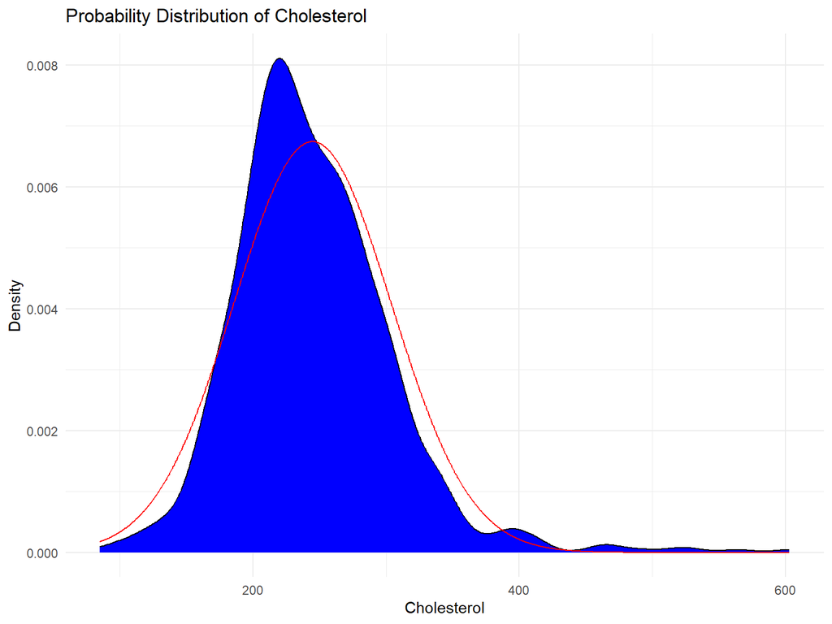

# Statistische Methode

- **Ziel:** Überprüfung der Hypothese, ob Brustschmerztypen den Ruheblutdruck beeinflussen.
- **Methode:** Varianzanalyse (ANOVA) gefolgt von einem Tukey-HSD-Test.

# Ergebnisse

|  | Df | Sum Sq | Mean Sq | F value | Pr(>F) |
| --- | --- | --- | --- | --- | --- |
| ChestPainType | 3 | 3101 | 1033.8 | 3.496 | 0.0153 * |
| Residuals | 742 | 219425 | 295.7 |  |  |

Significance Codes: 0 ‘***’ 0.001 ‘**’ 0.01 ‘*’ 0.05 ‘.’ 0.1 ‘ ’ 1

# Ergebnisse

| Comparison | Difference | Lower Bound | Upper Bound | Adjusted p |
| --- | --- | --- | --- | --- |
| ATA-ASY | -3.833735 | -7.970138 | 0.302668 | 0.0805519 |
| NAP-ASY | -3.110059 | -7.221041 | 1.000922 | 0.2090459 |
| TA-ASY | 3.282927 | -4.005327 | 10.57118 | 0.6524202 |
| NAP-ATA | 0.723676 | -4.114931 | 5.562283 | 0.9805744 |
| TA-ATA | 7.116662 | -0.605423 | 14.83875 | 0.0832181 |
| TA-NAP | 6.392986 | -1.315511 | 14.10148 | 0.1428788 |

# Schlussfolgerung

- Die Analyse deutet auf eine komplexe Beziehung zwischen Brustschmerztyp und Ruheblutdruck hin.
- Weitere Forschung ist notwendig, um diese Beziehungen vollständig zu verstehen und die Ursachen von Herzkrankheiten besser zu identifizieren.

# Repository-Link

- Besuchen Sie unser GitHub-Repository für den vollständigen Code und weitere Details: [**GitHub-Link**](https://gitlab.lrz.de/kirill_khvastow/r-projekt-gruppe-99)